# Home Credit Default Risk

Megan Beckett

16 July 2018

# 1 Introduction

The purpose of this notebook is to show my approach, exploration and findings for the Kaggle competition being run by Home Credit with the question:

- **Can you predict how capable each applicant is of repaying a loan?**

There are several datasets provided, but in this analysis I have focused on the main application dataset, with some exploration of the Bureau dataset.

This notebook includes my exploratory data analysis (step 00) and the subsequent steps are in R_scripts, with my general approach being:

- **00_explore:** Exploratory data analysis
- **01_preprocess:** Steps I took to clean and preprocess the data
- **02_model:** Training the model (I’ve left a few iterations in to show how it evolved)
- **03_test:** Evaluate model, look at importance of variables and make predictions on test dataset
- **04_submit:** Code for creating Kaggle submission file

# 2 Set up

## 2.1 Load packages required

Other packages required in subsequent steps are at the top of the relevant R_script.

```r
library(summarytools)
```

[output not shown]

## 2.2 Read in datasets

These are app_train, app_test and bureau.

```r
app_train <- read_csv("../raw_data/application_train.csv")
```

```r
app_test <- read_csv("../raw_data/application_test.csv")
```

```r
bureau <- read_csv("../raw_data/bureau.csv")
```

# 3 Overview of dataset

## 3.1 Summaries

Notes:

- I normally use a combination of str(), summary(), glimpse() to do this and recently explored skim().
- For **skim()**, I like how it splits the summary statistics across variable type and shows a basic histogram for numerical types.
- Missing values are also shown and this, along with the histograms, gives some indication of what to explore further.
- Subsequent to this, I have now used the package **summarytools** and specifically, dfSummary(). The histogram plots are even better (although render quite small) and the developers are working to improve the html output to work with Rmarkdown.
- See this vignette: https://cran.r-project.org/web/packages/summarytools/vignettes/Recommendations-rmarkdown.html

```r
#str(app_train)
#summary(app_train)
#glimpse(app_train)
#skim(app_train)
```

View data using dfSummary() from summarytools package.

```r
view(dfSummary(app_train), method = 'render')
```

Data Frame Summary

app_train

**N**: 307511

| **No** | **Variable** | **Stats / Values** | **Freqs (% of Valid)** | **Graph** | **Valid** | **Missing** |
| --- | --- | --- | --- | --- | --- | --- |
| 1 | SK_ID_CURR [integer] | mean (sd) : 278180.52 (102790.18) min < med < max : 100002 < 278202 < 456255 IQR (CV) : 177997 (0.37) | 307511 distinct val. |  | 307511 (100%) | 0 (0%) |
| 2 | TARGET [integer] | mean (sd) : 0.08 (0.27) min < med < max : 0 < 0 < 1 IQR (CV) : 0 (3.37) | 0.00 : 282686 (91.9%) 1.00 : 24825 (8.1%) |  | 307511 (100%) | 0 (0%) |
| 3 | NAME_CONTRACT_TYPE [character] | 1. Cash loans 2. Revolving loans | 278232 (90.5%) 29279 (9.5%) |  | 307511 (100%) | 0 (0%) |
| 4 | CODE_GENDER [character] | 1. F 2. M 3. XNA | 202448 (65.8%) 105059 (34.2%) 4 (0.0%) |  | 307511 (100%) | 0 (0%) |
| 5 | FLAG_OWN_CAR [character] | 1. N 2. Y | 202924 (66.0%) 104587 (34.0%) |  | 307511 (100%) | 0 (0%) |
| 6 | FLAG_OWN_REALTY [character] | 1. N 2. Y | 94199 (30.6%) 213312 (69.4%) |  | 307511 (100%) | 0 (0%) |
| 7 | CNT_CHILDREN [integer] | mean (sd) : 0.42 (0.72) min < med < max : 0 < 0 < 19 IQR (CV) : 1 (1.73) | 15 distinct val. |  | 307511 (100%) | 0 (0%) |
| 8 | AMT_INCOME_TOTAL [numeric] | mean (sd) : 168797.92 (237123.15) min < med < max : 25650 < 147150 < 1.17e+08 IQR (CV) : 90000 (1.4) | 2548 distinct val. |  | 307511 (100%) | 0 (0%) |
| 9 | AMT_CREDIT [numeric] | mean (sd) : 599026 (402490.78) min < med < max : 45000 < 513531 < 4050000 IQR (CV) : 538650 (0.67) | 5603 distinct val. |  | 307511 (100%) | 0 (0%) |
| 10 | AMT_ANNUITY [numeric] | mean (sd) : 27108.57 (14493.74) min < med < max : 1615.5 < 24903 < 258025.5 IQR (CV) : 18072 (0.53) | 13672 distinct val. |  | 307499 (100%) | 12 (0%) |
| 11 | AMT_GOODS_PRICE [numeric] | mean (sd) : 538396.21 (369446.46) min < med < max : 40500 < 450000 < 4050000 IQR (CV) : 441000 (0.69) | 1002 distinct val. |  | 307233 (99.91%) | 278 (0.09%) |
| 12 | NAME_TYPE_SUITE [character] | 1. Children 2. Family 3. Group of people 4. Other_A 5. Other_B 6. Spouse, partner 7. Unaccompanied | 3267 (1.1%) 40149 (13.1%) 271 (0.1%) 866 (0.3%) 1770 (0.6%) 11370 (3.7%) 248526 (81.2%) |  | 306219 (99.58%) | 1292 (0.42%) |
| 13 | NAME_INCOME_TYPE [character] | 1. Businessman 2. Commercial associate 3. Maternity leave 4. Pensioner 5. State servant 6. Student 7. Unemployed 8. Working | 10 (0.0%) 71617 (23.3%) 5 (0.0%) 55362 (18.0%) 21703 (7.1%) 18 (0.0%) 22 (0.0%) 158774 (51.6%) |  | 307511 (100%) | 0 (0%) |
| 14 | NAME_EDUCATION_TYPE [character] | 1. Academic degree 2. Higher education 3. Incomplete higher 4. Lower secondary 5. Secondary / secondary spe | 164 (0.1%) 74863 (24.3%) 10277 (3.3%) 3816 (1.2%) 218391 (71.0%) |  | 307511 (100%) | 0 (0%) |
| 15 | NAME_FAMILY_STATUS [character] | 1. Civil marriage 2. Married 3. Separated 4. Single / not married 5. Unknown 6. Widow | 29775 (9.7%) 196432 (63.9%) 19770 (6.4%) 45444 (14.8%) 2 (0.0%) 16088 (5.2%) |  | 307511 (100%) | 0 (0%) |
| 16 | NAME_HOUSING_TYPE [character] | 1. Co-op apartment 2. House / apartment 3. Municipal apartment 4. Office apartment 5. Rented apartment 6. With parents | 1122 (0.4%) 272868 (88.7%) 11183 (3.6%) 2617 (0.9%) 4881 (1.6%) 14840 (4.8%) |  | 307511 (100%) | 0 (0%) |
| 17 | REGION_POPULATION_RELATIVE [numeric] | mean (sd) : 0.02 (0.01) min < med < max : 0 < 0.02 < 0.07 IQR (CV) : 0.02 (0.66) | 81 distinct val. |  | 307511 (100%) | 0 (0%) |
| 18 | DAYS_BIRTH [integer] | mean (sd) : -16037 (4363.99) min < med < max : -25229 < -15750 < -7489 IQR (CV) : 7269 (-0.27) | 17460 distinct val. |  | 307511 (100%) | 0 (0%) |
| 19 | DAYS_EMPLOYED [integer] | mean (sd) : 63815.05 (141275.77) min < med < max : -17912 < -1213 < 365243 IQR (CV) : 2471 (2.21) | 12574 distinct val. |  | 307511 (100%) | 0 (0%) |
| 20 | DAYS_REGISTRATION [numeric] | mean (sd) : -4986.12 (3522.89) min < med < max : -24672 < -4504 < 0 IQR (CV) : 5469.5 (-0.71) | 15688 distinct val. |  | 307511 (100%) | 0 (0%) |
| 21 | DAYS_ID_PUBLISH [integer] | mean (sd) : -2994.2 (1509.45) min < med < max : -7197 < -3254 < 0 IQR (CV) : 2579 (-0.5) | 6168 distinct val. |  | 307511 (100%) | 0 (0%) |
| 22 | OWN_CAR_AGE [numeric] | mean (sd) : 12.06 (11.94) min < med < max : 0 < 9 < 91 IQR (CV) : 10 (0.99) | 62 distinct val. |  | 104582 (34.01%) | 202929 (65.99%) |
| 23 | FLAG_MOBIL [integer] | mean (sd) : 1 (0) min < med < max : 0 < 1 < 1 IQR (CV) : 0 (0) | 0.00 : 1 (0.0%) 1.00 : 307510 (100.0%) |  | 307511 (100%) | 0 (0%) |
| 24 | FLAG_EMP_PHONE [integer] | mean (sd) : 0.82 (0.38) min < med < max : 0 < 1 < 1 IQR (CV) : 0 (0.47) | 0.00 : 55386 (18.0%) 1.00 : 252125 (82.0%) |  | 307511 (100%) | 0 (0%) |
| 25 | FLAG_WORK_PHONE [integer] | mean (sd) : 0.2 (0.4) min < med < max : 0 < 0 < 1 IQR (CV) : 0 (2) | 0.00 : 246203 (80.1%) 1.00 : 61308 (19.9%) |  | 307511 (100%) | 0 (0%) |
| 26 | FLAG_CONT_MOBILE [integer] | mean (sd) : 1 (0.04) min < med < max : 0 < 1 < 1 IQR (CV) : 0 (0.04) | 0.00 : 574 (0.2%) 1.00 : 306937 (99.8%) |  | 307511 (100%) | 0 (0%) |
| 27 | FLAG_PHONE [integer] | mean (sd) : 0.28 (0.45) min < med < max : 0 < 0 < 1 IQR (CV) : 1 (1.6) | 0.00 : 221080 (71.9%) 1.00 : 86431 (28.1%) |  | 307511 (100%) | 0 (0%) |
| 28 | FLAG_EMAIL [integer] | mean (sd) : 0.06 (0.23) min < med < max : 0 < 0 < 1 IQR (CV) : 0 (4.08) | 0.00 : 290069 (94.3%) 1.00 : 17442 (5.7%) |  | 307511 (100%) | 0 (0%) |
| 29 | OCCUPATION_TYPE [character] | 1. Laborers 2. Sales staff 3. Core staff 4. Managers 5. Drivers 6. High skill tech staff 7. Accountants 8. Medicine staff 9. Security staff 10. Cooking staff [ 8 others ] | 55186 (26.1%) 32102 (15.2%) 27570 (13.1%) 21371 (10.1%) 18603 (8.8%) 11380 (5.4%) 9813 (4.7%) 8537 (4.0%) 6721 (3.2%) 5946 (2.8%) 13891 (6.6%) |  | 211120 (68.65%) | 96391 (31.35%) |
| 30 | CNT_FAM_MEMBERS [numeric] | mean (sd) : 2.15 (0.91) min < med < max : 1 < 2 < 20 IQR (CV) : 1 (0.42) | 17 distinct val. |  | 307509 (100%) | 2 (0%) |

[output cut: 92 more lines]

Generated by summarytools 0.8.5 ([R](https://www.r-project.org/) version 3.2.3)  
2018-07-19

## 3.2 Data types of variables

```r
table(sapply(app_train, class))
```

```
character   integer   numeric
       16        41        65
```

Notes:

- There are 16 categorical (character) variables to convert to factors.
- If I’d used read.csv, they could be converted automatically to factors, but read_csv is much faster.

# 4 Exploring missing values

## 4.1 Total missing values

```r
# Total missing values
total_missing = sum(is.na(app_train))
print(c("Total missing values in application train dataset:", total_missing))
```

```
[1] "Total missing values in application train dataset:" "9152465"
```

## 4.2 Missing values per variable

```r
# Absolute missing values per column
missing_val_abs <- colSums(is.na(app_train))
# Percentage missing values per column
missing_val_per <- missing_val_abs/nrow(app_train)*100
# Get column names
colnames <- colnames(app_train)
# Create dataframe of missing values and display as datatable
missing_summary = subset(data.frame(missing_val_abs, missing_val_per), missing_val_per>0)
missing_summary %>% datatable(filter = 'top', colnames = c('Total missing values', 'Percentage missing values'),
            options = list(pageLength = 15, autoWidth = F, order = list(2, 'desc')))
```

|  | Total missing values | Percentage missing values |
| --- | --- | --- |
| AMT_ANNUITY | 12 | 0.00390229942993909 |
| AMT_GOODS_PRICE | 278 | 0.0904032701269223 |
| NAME_TYPE_SUITE | 1292 | 0.420147571956776 |
| OWN_CAR_AGE | 202929 | 65.9908100848425 |
| OCCUPATION_TYPE | 96391 | 31.3455453626049 |
| CNT_FAM_MEMBERS | 2 | 0.000650383238323182 |
| EXT_SOURCE_1 | 173378 | 56.3810725469983 |
| EXT_SOURCE_2 | 660 | 0.21462646864665 |
| EXT_SOURCE_3 | 60965 | 19.8253070621864 |
| APARTMENTS_AVG | 156061 | 50.7497292779771 |

[output cut: 57 more lines]

Notes:

- There are 67 variables in total with missing values.
- 49 variables have over 40% missing values.
- A large portion of these are to do with the decription of the typeof property.

# 5 Exploration of single variables

## 5.1 TARGET classification

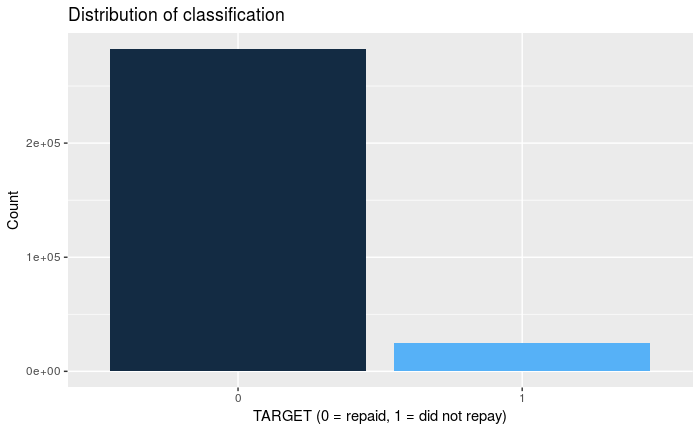

```r
# Target variable - classification
app_train %>%
  count(TARGET) %>%
  arrange(desc(n)) %>%
  ggplot(aes(reorder(TARGET, -n, FUN = min), n, fill = TARGET)) +
  geom_col() +
  theme(legend.position = "none") +
  labs(x = 'TARGET (0 = repaid, 1 = did not repay)',y = 'Count') +
  ggtitle("Distribution of classification")
```

Notes:

- Binary classification (0 if loan repaid, 1 if loan not repaid).
- There are many more loans paid on time than there aren’t.

## 5.2 Quantitative variable exploration

Notes:

- All of the numerical variables shown here are right skewed.
- This is can be dealt with in preprocessing, but I have left them as is for now.

### 5.2.1 Distribution of amount of credit

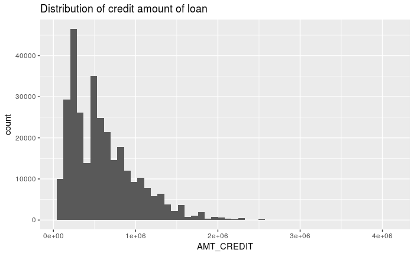

```r
ggplot(app_train, aes(AMT_CREDIT)) +
  geom_histogram(bins = 50) +
  ggtitle("Distribution of credit amount of loan")
```

### 5.2.2 Distribution of loan annuity

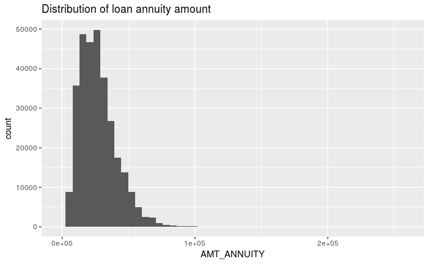

```r
ggplot(app_train, aes(AMT_ANNUITY)) +
  geom_histogram(bins = 50) +
  ggtitle("Distribution of loan annuity amount")
```

### 5.2.3 Distribution of goods price

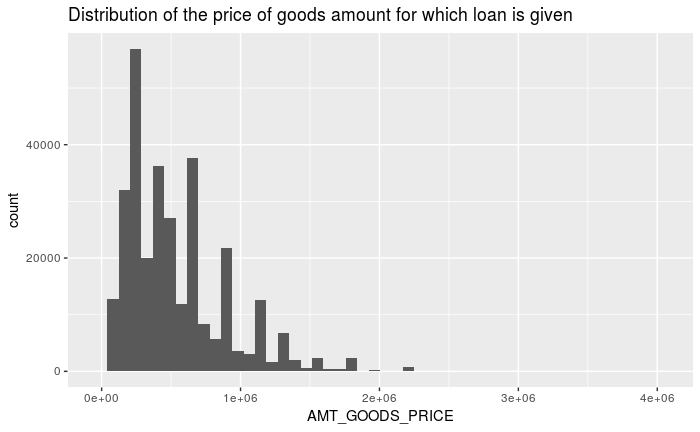

```r
ggplot(app_train, aes(AMT_GOODS_PRICE)) +
  geom_histogram(bins = 50) +
  ggtitle("Distribution of the price of goods amount for which loan is given")
```

### 5.2.4 Income distribution

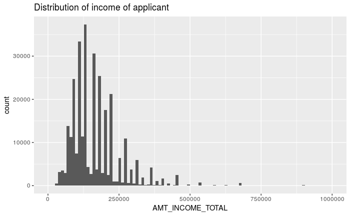

```r
ggplot(app_train, aes(AMT_INCOME_TOTAL)) +
  geom_histogram(bins= 100) +
  xlim(0,1000000) +
  ggtitle("Distribution of income of applicant")
```

Summary of AMT_INCOME_TOTAL for app_train and app_test, respectively:

```r
summary(app_train$AMT_INCOME_TOTAL)
```

```
     Min.   1st Qu.    Median      Mean   3rd Qu.      Max.
    25650    112500    147200    168800    202500 117000000
```

```r
summary(app_test$AMT_INCOME_TOTAL)
```

```
   Min. 1st Qu.  Median    Mean 3rd Qu.    Max.
  26940  112500  157500  178400  225000 4410000
```

Notes: There is a really large outlier of 117000000 for total income. It seems unlikely that such an individual would be applying for a loan and this could be a mistake. Consider replacing with NA during data cleaning.

## 5.3 Categorical variable exploration

### 5.3.1 Type of loan

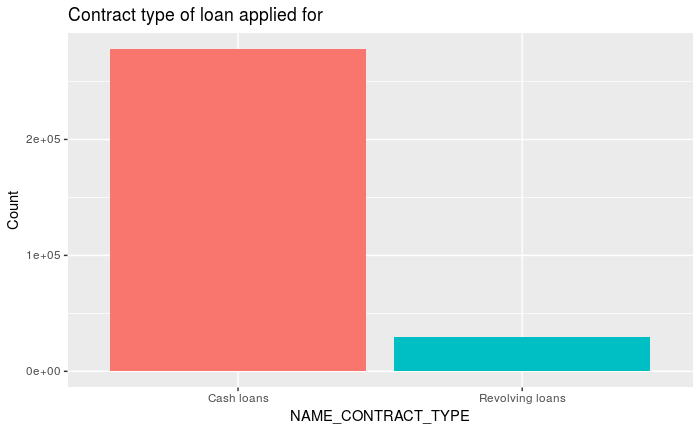

```r
app_train %>%
  count(NAME_CONTRACT_TYPE) %>%
  arrange(desc(n)) %>%
  ggplot(aes(reorder(NAME_CONTRACT_TYPE, -n, FUN = min), n, fill = NAME_CONTRACT_TYPE)) +
  geom_col() +
  theme(legend.position = "none") +
  labs(x = 'NAME_CONTRACT_TYPE',y = 'Count') +
  ggtitle("Contract type of loan applied for")
```

Note: Predominant loan type is cash loan.

### 5.3.2 Gender

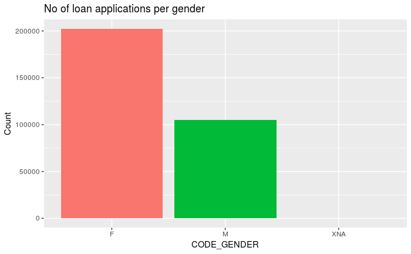

```r
app_train %>%
  count(CODE_GENDER) %>%
  arrange(desc(n)) %>%
  ggplot(aes(reorder(CODE_GENDER, -n, FUN = min), n, fill = CODE_GENDER)) +
  geom_col() +
  theme(legend.position = "none") +
  labs(x = 'CODE_GENDER',y = 'Count') +
  ggtitle("No of loan applications per gender")
```

Note: More females applying for loans than males.

### 5.3.3 Own a car

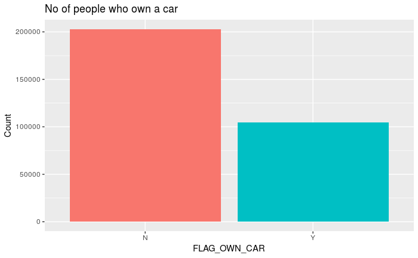

```r
app_train %>%
  count(FLAG_OWN_CAR) %>%
  arrange(desc(n)) %>%
  ggplot(aes(reorder(FLAG_OWN_CAR, -n, FUN = min), n, fill = FLAG_OWN_CAR)) +
  geom_col() +
  theme(legend.position = "none") +
  labs(x = 'FLAG_OWN_CAR',y = 'Count') +
  ggtitle("No of people who own a car")
```

Note: About 50% less people own a car than those who don’t

### 5.3.4 Own any property

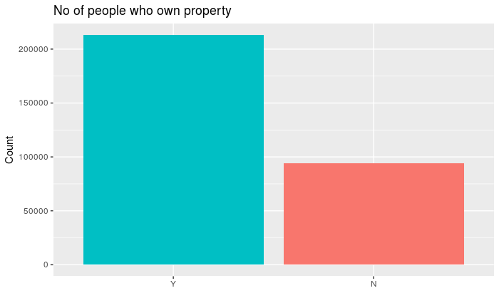

```r
app_train %>%
  count(FLAG_OWN_REALTY) %>%
  arrange(desc(n)) %>%
  ggplot(aes(reorder(FLAG_OWN_REALTY, -n, FUN = min), n, fill = FLAG_OWN_REALTY)) +
  geom_col() +
  theme(legend.position = "none") +
  labs(x = '',y = 'Count') +
  ggtitle("No of people who own property")
```

Note: Unlike owning a car, there are many more who own property

### 5.3.5 Level of education of loan applicants

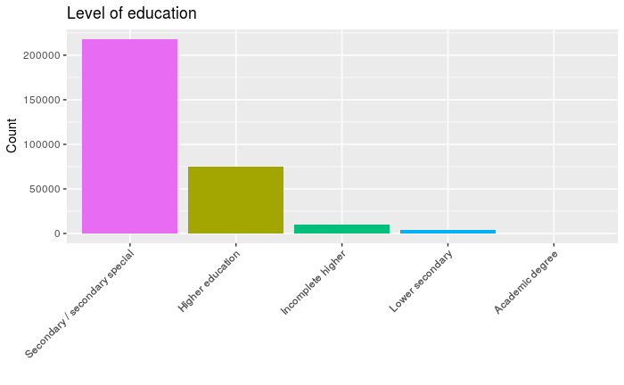

```r
app_train %>%
  count(NAME_EDUCATION_TYPE) %>%
  arrange(desc(n)) %>%
  ggplot(aes(reorder(NAME_EDUCATION_TYPE, -n, FUN = min), n, fill = NAME_EDUCATION_TYPE)) +
  geom_col() +
  theme(legend.position = "none") +
  labs(x = '',y = 'Count') +
  theme(axis.text.x = element_text(angle = 45, hjust=1)) +
  ggtitle("Level of education")
```

Notes: The majority have completed secondary school. There are a few with incomplete highschool or only lower secondary. This is an interesting flag.

### 5.3.6 Income level of applicants

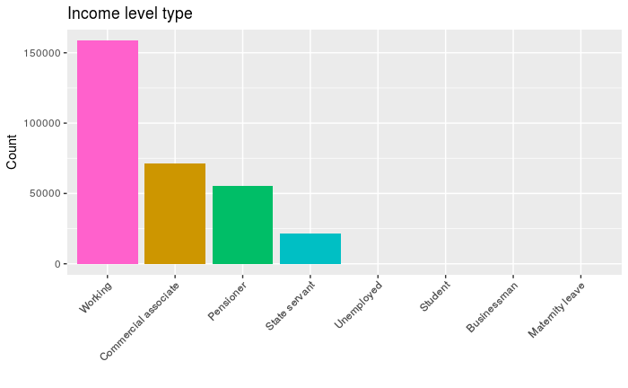

```r
app_train %>%
  count(NAME_INCOME_TYPE) %>%
  arrange(desc(n)) %>%
  ggplot(aes(reorder(NAME_INCOME_TYPE, -n, FUN = min), n, fill = NAME_INCOME_TYPE)) +
  geom_col() +
  theme(legend.position = "none") +
  labs(x = '',y = 'Count') +
  theme(axis.text.x = element_text(angle = 45, hjust=1)) +
  ggtitle("Income level type")
```

Notes: The majority are working. There is a significant portion of pensioners, which is interesting. There are also some unemployed, students and those on materynity leave.

# 6 Exploration of variables measuring time/age

## 6.1 Age of clients

```r
summary(app_train$DAYS_BIRTH)
```

```
   Min. 1st Qu.  Median    Mean 3rd Qu.    Max.
 -25230  -19680  -15750  -16040  -12410   -7489
```

Notes:

- Interesting, these are negative numbers.
- According to Home Credit, these numbers indicate the relative age of person in number of days backwards from loan application date.

Convert numbers to absolute value and in years to view a meaningful plot.

```r
age = as.data.frame(app_train$DAYS_BIRTH/(-365))
colnames(age) = 'AGE_YEARS'
summary(age)
```

```
   AGE_YEARS
 Min.   :20.52
 1st Qu.:34.01
 Median :43.15
 Mean   :43.94
 3rd Qu.:53.92
 Max.   :69.12
```

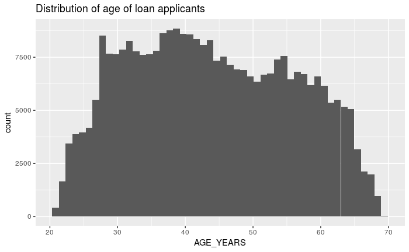

```r
ggplot(age, aes(AGE_YEARS)) +
  geom_histogram(bins = 50) +
  ggtitle("Distribution of age of loan applicants")
```

Notes: Median age is in the 40’s and there is a wide distribution in ages from 20 to 70 years old.

# 7 Days of employment

```r
summary(app_train$DAYS_EMPLOYED)
```

```
   Min. 1st Qu.  Median    Mean 3rd Qu.    Max.
 -17910   -2760   -1213   63820    -289  365200
```

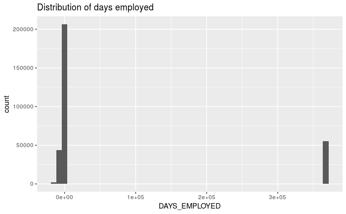

```r
ggplot(app_train, aes(DAYS_EMPLOYED)) +
  geom_histogram(bins = 50) +
  ggtitle("Distribution of days employed")
```

Notes:

- As with age in number of days, days of emplyment is no days before the application the person started current employment.
- Median is -1213 which is about 3 years prior to application.
- But, positive numbers don’t make sense and there are massive outliers equating to about 1000 years (365243 days)

Create subset of these outliers to investigate.

```r
employed_outliers <- subset(app_train, DAYS_EMPLOYED > 0)
employed_normal <- subset(app_train, DAYS_EMPLOYED <= 0)
print("Summary of outliers TARGET")
```

```
[1] "Summary of outliers TARGET"
```

```r
summary(employed_outliers$TARGET)
```

```
   Min. 1st Qu.  Median    Mean 3rd Qu.    Max.
  0.000   0.000   0.000   0.054   0.000   1.000
```

```r
print("Summary of normal TARGET")
```

```
[1] "Summary of normal TARGET"
```

```r
summary(employed_normal$TARGET)
```

```
   Min. 1st Qu.  Median    Mean 3rd Qu.    Max.
 0.0000  0.0000  0.0000  0.0866  0.0000  1.0000
```

Notes:

- The outliers (all have same value of 365243 days) only default on 5.4% of loans whereas those with reasonable employment records, don’t repay 8.66% of time.
- Investigate later by replacing these values with NA before imputation to replace missing values and see if has an effect.

# 8 A quick look at additional datasets

## 8.1 Bureau

```r
summary(bureau)
```

```
   SK_ID_CURR      SK_ID_BUREAU     CREDIT_ACTIVE      CREDIT_CURRENCY     DAYS_CREDIT    CREDIT_DAY_OVERDUE
 Min.   :100001   Min.   :5000000   Length:1716428     Length:1716428     Min.   :-2922   Min.   :   0.0000
 1st Qu.:188867   1st Qu.:5463954   Class :character   Class :character   1st Qu.:-1666   1st Qu.:   0.0000
 Median :278055   Median :5926304   Mode  :character   Mode  :character   Median : -987   Median :   0.0000
 Mean   :278215   Mean   :5924434                                         Mean   :-1142   Mean   :   0.8182
 3rd Qu.:367426   3rd Qu.:6385681                                         3rd Qu.: -474   3rd Qu.:   0.0000
 Max.   :456255   Max.   :6843457                                         Max.   :    0   Max.   :2792.0000

 DAYS_CREDIT_ENDDATE DAYS_ENDDATE_FACT AMT_CREDIT_MAX_OVERDUE CNT_CREDIT_PROLONG AMT_CREDIT_SUM      AMT_CREDIT_SUM_DEBT
 Min.   :-42060.0    Min.   :-42023    Min.   :        0      Min.   :0.00000    Min.   :        0   Min.   : -4705600
 1st Qu.: -1138.0    1st Qu.: -1489    1st Qu.:        0      1st Qu.:0.00000    1st Qu.:    51300   1st Qu.:        0
 Median :  -330.0    Median :  -897    Median :        0      Median :0.00000    Median :   125518   Median :        0
 Mean   :   510.5    Mean   : -1017    Mean   :     3825      Mean   :0.00641    Mean   :   354995   Mean   :   137085
 3rd Qu.:   474.0    3rd Qu.:  -425    3rd Qu.:        0      3rd Qu.:0.00000    3rd Qu.:   315000   3rd Qu.:    40154
 Max.   : 31199.0    Max.   :     0    Max.   :115987185      Max.   :9.00000    Max.   :585000000   Max.   :170100000
 NA's   :105553      NA's   :633653    NA's   :1124488                           NA's   :13          NA's   :257669
 AMT_CREDIT_SUM_LIMIT AMT_CREDIT_SUM_OVERDUE CREDIT_TYPE        DAYS_CREDIT_UPDATE  AMT_ANNUITY
 Min.   :-586406      Min.   :      0        Length:1716428     Min.   :-41947.0   Min.   :        0
 1st Qu.:      0      1st Qu.:      0        Class :character   1st Qu.:  -908.0   1st Qu.:        0
 Median :      0      Median :      0        Mode  :character   Median :  -395.0   Median :        0
 Mean   :   6230      Mean   :     38                           Mean   :  -593.8   Mean   :    15713
 3rd Qu.:      0      3rd Qu.:      0                           3rd Qu.:   -33.0   3rd Qu.:    13500
 Max.   :4705600      Max.   :3756681                           Max.   :   372.0   Max.   :118453424
 NA's   :591780                                                                    NA's   :1226791
```

```r
skim(bureau)
```

```
Skim summary statistics
 n obs: 1716428
 n variables: 17

── Variable type:character ───────────────────────────────────────────────────────────────────────────────────────────────────
        variable missing complete       n min max empty n_unique
   CREDIT_ACTIVE       0  1716428 1716428   4   8     0        4
 CREDIT_CURRENCY       0  1716428 1716428  10  10     0        4
     CREDIT_TYPE       0  1716428 1716428   8  44     0       15

── Variable type:integer ─────────────────────────────────────────────────────────────────────────────────────────────────────
           variable missing complete       n         mean         sd     p0        p25       p50        p75    p100     hist
 CNT_CREDIT_PROLONG       0  1716428 1716428       0.0064      0.096      0       0          0         0          9 ▇▁▁▁▁▁▁▁
 CREDIT_DAY_OVERDUE       0  1716428 1716428       0.82       36.54       0       0          0         0       2792 ▇▁▁▁▁▁▁▁
        DAYS_CREDIT       0  1716428 1716428   -1142.11      795.16   -2922   -1666       -987      -474          0 ▃▃▂▅▆▇▇▇
 DAYS_CREDIT_UPDATE       0  1716428 1716428    -593.75      720.75  -41947    -908       -395       -33        372 ▁▁▁▁▁▁▁▇
       SK_ID_BUREAU       0  1716428 1716428 5924434.49   532265.73   5e+06 5463953.75 5926303.5 6385681.25 6843457 ▇▇▇▇▇▇▇▇
         SK_ID_CURR       0  1716428 1716428  278214.93    1e+05      1e+05  188866.75  278055    367426     456255 ▇▇▇▇▇▇▇▇

── Variable type:numeric ─────────────────────────────────────────────────────────────────────────────────────────────────────
               variable missing complete       n      mean         sd          p0   p25      p50      p75          p100
            AMT_ANNUITY 1226791   489637 1716428  15712.76  325826.95        0        0      0    13500         1.2e+08
 AMT_CREDIT_MAX_OVERDUE 1124488   591940 1716428   3825.42  206031.61        0        0      0        0         1.2e+08
         AMT_CREDIT_SUM      13  1716415 1716428 354994.59 1149811.34        0    51300 125518.5 315000         5.8e+08
    AMT_CREDIT_SUM_DEBT  257669  1458759 1716428 137085.12  677401.13 -4705600.32     0      0    40153.5       1.7e+08
   AMT_CREDIT_SUM_LIMIT  591780  1124648 1716428   6229.51   45032.03  -586406.11     0      0        0   4705600.32
 AMT_CREDIT_SUM_OVERDUE       0  1716428 1716428     37.91    5937.65        0        0      0        0   3756681
    DAYS_CREDIT_ENDDATE  105553  1610875 1716428    510.52    4994.22   -42060    -1138   -330      474     31199
      DAYS_ENDDATE_FACT  633653  1082775 1716428  -1017.44     714.01   -42023    -1489   -897     -425         0
     hist
 ▇▁▁▁▁▁▁▁
 ▇▁▁▁▁▁▁▁
 ▇▁▁▁▁▁▁▁
 ▇▁▁▁▁▁▁▁
 ▇▁▁▁▁▁▁▁
 ▇▁▁▁▁▁▁▁
 ▁▁▁▁▇▁▁▁
 ▁▁▁▁▁▁▁▇
```

What are the unique values for the variable CREDIT_ACTIVE?

```r
unique(bureau$CREDIT_ACTIVE)
```

```
[1] "Closed"   "Active"   "Sold"     "Bad debt"
```

Notes:

- After first doing a logistic regression using only the applications data set, I am going to see what features I can create from the Bureau data set by grouping according to the loan id and then calculating some sums of numerical values of interest.
- I think the interesting ones to look at are:
- CREDIT_DAY_OVERDUE: Number of days past due on CB credit at the time of application for related loan in our sample
- AMT_CREDIT_SUM: Current credit amount for the Credit Bureau credit
- AMT_CREDIT_SUM_DEBT: Current debt on Credit Bureau credit
- AMT_CREDIT_SUM_OVERDUE: Current amount overdue on Credit Bureau credit

## 8.2 Previous application

```r
summary(app_prev)
```

```
   SK_ID_PREV        SK_ID_CURR     NAME_CONTRACT_TYPE  AMT_ANNUITY     AMT_APPLICATION     AMT_CREDIT
 Min.   :1000001   Min.   :100001   Length:1670214     Min.   :     0   Min.   :      0   Min.   :      0
 1st Qu.:1461857   1st Qu.:189329   Class :character   1st Qu.:  6322   1st Qu.:  18720   1st Qu.:  24160
 Median :1923110   Median :278714   Mode  :character   Median : 11250   Median :  71046   Median :  80541
 Mean   :1923089   Mean   :278357                      Mean   : 15955   Mean   : 175234   Mean   : 196114
 3rd Qu.:2384280   3rd Qu.:367514                      3rd Qu.: 20658   3rd Qu.: 180360   3rd Qu.: 216418
 Max.   :2845382   Max.   :456255                      Max.   :418058   Max.   :6905160   Max.   :6905160
                                                       NA's   :372235                     NA's   :1
 AMT_DOWN_PAYMENT    AMT_GOODS_PRICE   WEEKDAY_APPR_PROCESS_START HOUR_APPR_PROCESS_START FLAG_LAST_APPL_PER_CONTRACT
 Min.   :     -0.9   Min.   :      0   Length:1670214             Min.   : 0.00           Length:1670214
 1st Qu.:      0.0   1st Qu.:  50841   Class :character           1st Qu.:10.00           Class :character
 Median :   1638.0   Median : 112320   Mode  :character           Median :12.00           Mode  :character
 Mean   :   6697.4   Mean   : 227847                              Mean   :12.48
 3rd Qu.:   7740.0   3rd Qu.: 234000                              3rd Qu.:15.00
 Max.   :3060045.0   Max.   :6905160                              Max.   :23.00
 NA's   :895844      NA's   :385515
 NFLAG_LAST_APPL_IN_DAY RATE_DOWN_PAYMENT RATE_INTEREST_PRIMARY RATE_INTEREST_PRIVILEGED NAME_CASH_LOAN_PURPOSE
 Min.   :0.0000         Min.   :0.0       Min.   :0.0           Min.   :0.4              Length:1670214
 1st Qu.:1.0000         1st Qu.:0.0       1st Qu.:0.2           1st Qu.:0.7              Class :character
 Median :1.0000         Median :0.1       Median :0.2           Median :0.8              Mode  :character
 Mean   :0.9965         Mean   :0.1       Mean   :0.2           Mean   :0.8
 3rd Qu.:1.0000         3rd Qu.:0.1       3rd Qu.:0.2           3rd Qu.:0.9
 Max.   :1.0000         Max.   :1.0       Max.   :1.0           Max.   :1.0
                        NA's   :895844    NA's   :1664263       NA's   :1664263
 NAME_CONTRACT_STATUS DAYS_DECISION     NAME_PAYMENT_TYPE  CODE_REJECT_REASON NAME_TYPE_SUITE    NAME_CLIENT_TYPE
 Length:1670214       Min.   :-2922.0   Length:1670214     Length:1670214     Length:1670214     Length:1670214
 Class :character     1st Qu.:-1300.0   Class :character   Class :character   Class :character   Class :character
 Mode  :character     Median : -581.0   Mode  :character   Mode  :character   Mode  :character   Mode  :character
                      Mean   : -880.7
                      3rd Qu.: -280.0
                      Max.   :   -1.0

 NAME_GOODS_CATEGORY NAME_PORTFOLIO     NAME_PRODUCT_TYPE  CHANNEL_TYPE       SELLERPLACE_AREA  NAME_SELLER_INDUSTRY
 Length:1670214      Length:1670214     Length:1670214     Length:1670214     Min.   :     -1   Length:1670214
 Class :character    Class :character   Class :character   Class :character   1st Qu.:     -1   Class :character
 Mode  :character    Mode  :character   Mode  :character   Mode  :character   Median :      3   Mode  :character
                                                                              Mean   :    314
                                                                              3rd Qu.:     82
                                                                              Max.   :4000000

  CNT_PAYMENT     NAME_YIELD_GROUP   PRODUCT_COMBINATION DAYS_FIRST_DRAWING DAYS_FIRST_DUE   DAYS_LAST_DUE_1ST_VERSION
 Min.   : 0.0     Length:1670214     Length:1670214      Min.   : -2922     Min.   : -2892   Min.   : -2801
 1st Qu.: 6.0     Class :character   Class :character    1st Qu.:365243     1st Qu.: -1628   1st Qu.: -1242
 Median :12.0     Mode  :character   Mode  :character    Median :365243     Median :  -831   Median :  -361
 Mean   :16.1                                            Mean   :342210     Mean   : 13826   Mean   : 33768
 3rd Qu.:24.0                                            3rd Qu.:365243     3rd Qu.:  -411   3rd Qu.:   129
 Max.   :84.0                                            Max.   :365243     Max.   :365243   Max.   :365243
 NA's   :372230                                          NA's   :673065     NA's   :673065   NA's   :673065
 DAYS_LAST_DUE    DAYS_TERMINATION NFLAG_INSURED_ON_APPROVAL
 Min.   : -2889   Min.   : -2874   Min.   :0.0
 1st Qu.: -1314   1st Qu.: -1270   1st Qu.:0.0
 Median :  -537   Median :  -499   Median :0.0
 Mean   : 76582   Mean   : 81992   Mean   :0.3
 3rd Qu.:   -74   3rd Qu.:   -44   3rd Qu.:1.0
 Max.   :365243   Max.   :365243   Max.   :1.0
 NA's   :673065   NA's   :673065   NA's   :673065
```

What are the unique values for the variables CODE_REJECT_REASON and NAME_CONTRACT_STATUS, respectively?

```r
unique(app_prev$CODE_REJECT_REASON)
```

```
[1] "XAP"    "HC"     "LIMIT"  "CLIENT" "SCOFR"  "SCO"    "XNA"    "VERIF"  "SYSTEM"
```

```r
unique(app_prev$NAME_CONTRACT_STATUS)
```

```
[1] "Approved"     "Refused"      "Canceled"     "Unused offer"
```